# Examples of 2-D probability density functions estimated using histograms and KDE methods

In this script, we compare estimates of probability density functions (PDF) based on two popular methods:

- Standard histogram-based approach
- Kernel Density Estimation (KDE) with gaussian and Epanechikov kernels

The methods are applied to a dataset generated from a bivariate normal.

## Standard histogram-based PDF estimator

In this method, the probability density $\hat P(\bf{x})$ is proportional to the number of data points $\bf{x^{t}}$ inside the joint intervals $[x_{1}, x_{1}+h[$ and $[x_{2}, x_{2}+h[$

> $\hat P(\mathbf{x}) = \large{\frac{ \# \{\{x_{1}\le x_{1}^{t}< x_{1}+h \} \cap \{ x_{2}\le x_{2}^{t}< x_{2}+h \}\}}{Nh^{2}}} $

## KDE PDF estimator

In this method, the probability density $\hat P(\mathbf{x})$ is modeled as the convolution of the data distribution with a kernel $K(u)$ designed to smooth the experimental PDF

> $\hat P(\mathbf{x}) = \frac{1}{Nh}\sum_{t=1}^{N} K(\frac{x-x^{t}}{h})$

The level of smoothing is controled by the bandwidth parameter *h*.

Gaussian and Epanechikov are popular kernels. Their 1-D and 2-D expressions are:

> 1-D Gaussian: $K(u)= \frac{1}{\sqrt{2\pi}} \exp [-\frac{u^{2}}{2}]$

> 2-D Gaussian: $K(\bf{u})= \frac{1}{2\pi} \exp [-\frac{\|u\|^{2}}{2}]$

> 1-D Epanechikov: $K(u)= \frac{3}{4}(1-u^{2})$ for $u \in [-1, 1]$

> 2-D Epanechikov: $K(\bf{u})= \frac{15}{8\pi}(1-\|u\|^{2})$ for $u \in [0, 1]$

In this script, we only use the 2-D versions of the kernels.

```python
print(__doc__)

# Author: Pierre Gravel <pierre.gravel@iid.ulaval.ca>
# License: BSD

import numpy as np
import pandas as pd

import matplotlib.pyplot as plt
from matplotlib.image import NonUniformImage

from scipy.stats import multivariate_normal
from progress.bar import Bar

import seaborn as sns
sns.set()

# Used for reproductibility of the results
np.random.seed(42)
```

```
Automatically created module for IPython interactive environment
```

# True PDF generation

```python
# Parameters of the bivariate normal.
Mu = [2., 2.]

# Covariance matrix
sigma_x1 = 0.45
sigma_x2 = 0.9
rho = 0.9
Sigma = [(sigma_x1**2, rho*sigma_x1*sigma_x2), (rho*sigma_x1*sigma_x2, sigma_x2**2)]
```

Generate a spatial grid where the PDF will be evaluated locally. N.B. It will be evaluated in the center of each bin, not on the bin edges.

```python
x_min, x_max = 0., 4.
y_min, y_max = 0., 4.

# Positions of the bin edges
nbins = 50
xedges = np.linspace(x_min, x_max, nbins+1)
yedges = np.linspace(y_min, y_max, nbins+1)

# Positions of the bin centers
h = xedges[1] - xedges[0]
xedges = xedges[0:-1] + h/2
h = yedges[1] - yedges[0]
yedges = yedges[0:-1] + h/2

xx, yy = np.meshgrid(xedges, yedges)
pos = np.dstack((xx, yy))
Xgrid = np.c_[xx.ravel(), yy.ravel()]
```

Evaluate the PDF in the center of each grid element

```python
model = multivariate_normal(Mu, Sigma)
pdf_true = model.pdf(pos)
```

# Dataset generation

Create a bivariate normal dataset with $N_{pts}=10000$ data points.

```python
npts = 10000

X = np.random.multivariate_normal(Mu, Sigma, npts)
x = X[:,0]
y = X[:,1]
```

Show the dataset with its PDF

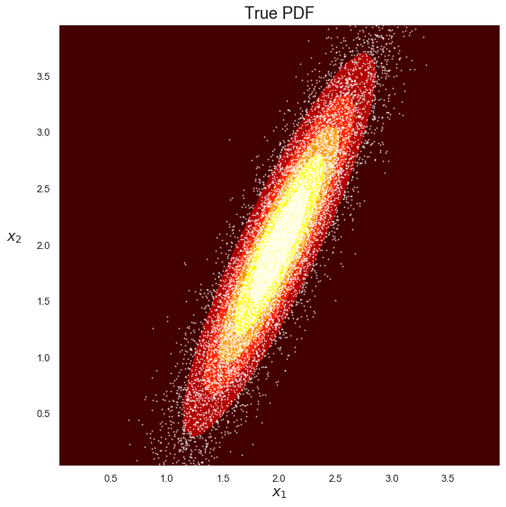

```python
cm = 'hot'

fig = plt.figure(figsize=(8, 8))
ax = fig.add_subplot(111, aspect='equal')
ax.contourf(xx, yy, pdf_true, cmap=cm)
ax.scatter(X[:, 0], X[:, 1], c="w", s=1, linewidth=1, marker="o", alpha=0.5)
ax.set_xlim([x_min+h/2,x_max-h/2])
ax.set_ylim([y_min+h/2,y_max-h/2])
ax.set_title('True PDF', fontsize=18, color='k')
ax.set_xlabel('$x_{1}$', fontsize=16)
ax.set_ylabel('$x_{2}$', fontsize=16, rotation=0)
ax.yaxis.set_label_coords(-0.1, 0.5)
ax.grid(None)


fig.tight_layout()
plt.savefig('2D_PDF_estimation_dataset_and_true_PDF.png')
plt.savefig('2D_PDF_estimation_dataset_and_true_PDF.pdf')
```

# Standard histogram-based PDF estimator

```python
nbins = 50
xedges = np.linspace(x_min, x_max, nbins+1)
yedges = np.linspace(y_min, y_max, nbins+1)

pdf_hist, xedges, yedges = np.histogram2d(x, y, bins=(xedges, yedges), density=True)
pdf_hist = pdf_hist.T  # Let each row list bins with common y range.
```

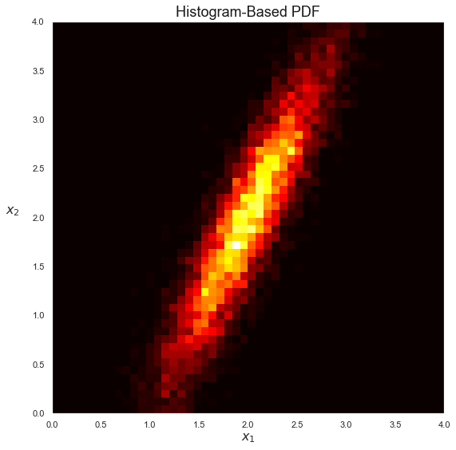

```python
fig = plt.figure(figsize=(8,8))
ax = fig.add_subplot(111, aspect='equal')
ax.imshow(pdf_hist, interpolation='nearest', origin='low',
        extent=[xedges[0], xedges[-1], yedges[0], yedges[-1]], cmap='hot')
ax.set_title('Histogram-Based PDF', fontsize=18, color='k')
ax.set_xlabel('$x_{1}$', fontsize=16)
ax.set_ylabel('$x_{2}$', fontsize=16, rotation=0)
ax.yaxis.set_label_coords(-0.1, 0.5)
ax.grid(None)

fig.tight_layout()
plt.savefig('2D_PDF_histogram_based_PDF.png')
plt.savefig('2D_PDF_histogram_based_PDF.pdf')
```

# KDE PDF estimators

These functions compute the KDE PDF estimations with the gaussian and the Epanechikov kernels.

```python
def compute_KDE_pdf(npts, h_gaussian, h_epanechikov, X, xx, Xgrid):

    pdf_g = np.zeros(xx.shape)
    pdf_e = np.zeros(xx.shape)

    for n in range(npts):
        dX = (X[n,:] - Xgrid)
        dX2 = dX[:,0]**2 + dX[:,1]**2

        u2 = dX2/h_gaussian**2
        pdf_g = pdf_g + gaussian_2D(u2).reshape(xx.shape)

        u2 = dX2/h_epanechikov**2
        pdf_e = pdf_e + epanechikov_2D(u2).reshape(xx.shape)

    # Normalisation
    pdf_g = pdf_g/(npts*h_gaussian**2)
    pdf_e = pdf_e/(npts*h_epanechikov**2)

    return (pdf_g, pdf_e)


# KDE kernels
def gaussian_2D(u2):
    y = np.exp(-u2/2)/(2*np.pi)
    return y

def epanechikov_2D(u2):
    y = (15/(8*np.pi))*(1-u2)
    indx = np.where(u2>=1)
    y[indx] = 0
    return y
```

This function compares the true PDF with the three estimated PDF; one histogram-based and two KDE-based.

```python
def compare_PDF(figName):

    vmax = np.max([pdf_true.max(), pdf_hist.max(), pdf_KDE_gauss.max(), pdf_KDE_epa.max()])

    fig, axs = plt.subplots(2,2, figsize=(10, 10), sharex=True, sharey=True)
    for k in range(4):
        if (k==0):
            axs[0,0].imshow(pdf_true, interpolation='nearest', origin='low',
                extent=[xedges[0], xedges[-1], yedges[0], yedges[-1]], cmap=cm, vmin=0, vmax=vmax)
            axs[0,0].set_title('True PDF', fontsize=18, color='k')
            axs[0,0].set_xlabel('$x_{1}$', fontsize=14)
            axs[0,0].set_ylabel('$x_{2}$', fontsize=14, rotation=0)
            axs[0,0].yaxis.set_label_coords(-0.15, 0.5)
            axs[0,0].grid(None)
        elif (k==1):
            axs[0,1].imshow(pdf_hist, interpolation='nearest', origin='low',
                extent=[xedges[0], xedges[-1], yedges[0], yedges[-1]], cmap=cm, vmin=0, vmax=vmax)
            axs[0,1].set_title('Histogram', fontsize=18, color='k')
            axs[0,1].set_xlabel('$x_{1}$', fontsize=14)
            axs[0,1].set_ylabel('$x_{2}$', fontsize=14, rotation=0)
            axs[0,1].yaxis.set_label_coords(-0.15, 0.5)
            axs[0,1].grid(None)
        elif (k==2):
            axs[1,0].imshow(pdf_KDE_gauss, interpolation='nearest', origin='low',
                extent=[xedges[0], xedges[-1], yedges[0], yedges[-1]], cmap=cm, vmin=0, vmax=vmax)
            axs[1,0].set_title('KDE (Gaussian Kernel)', fontsize=18, color='k')
            axs[1,0].set_xlabel('$x_{1}$', fontsize=14)
            axs[1,0].set_ylabel('$x_{2}$', fontsize=14, rotation=0)
            axs[1,0].yaxis.set_label_coords(-0.15, 0.5)
            axs[1,0].grid(None)
        else:
            axs[1,1].imshow(pdf_KDE_epa, interpolation='nearest', origin='low',
                extent=[xedges[0], xedges[-1], yedges[0], yedges[-1]], cmap=cm, vmin=0, vmax=vmax)
            axs[1,1].set_title('KDE (Epanechikov Kernel)', fontsize=18, color='k')
            axs[1,1].set_xlabel('$x_{1}$', fontsize=14)
            axs[1,1].set_ylabel('$x_{2}$', fontsize=14, rotation=0)
            axs[1,1].yaxis.set_label_coords(-0.15, 0.5)
            axs[1,1].grid(None)

    fig.tight_layout()
    plt.savefig(figName + '.png')
    plt.savefig(figName + '.pdf')
```

This function compares the individual PDF along an horizontal cross section passing through the PDF origin. This corresponds to measurements of conditional probability $P(x_{1}|x_{2}=2)$.

```python
def compare_conditional_PDF(figName):
    fig, axs = plt.subplots(1,2,figsize=(15,5))

    axs[0].imshow(pdf_true, interpolation='nearest', origin='low',
        extent=[xedges[0], xedges[-1], yedges[0], yedges[-1]], cmap=cm)
    axs[0].plot(xx[0,:],2*np.ones((nbins,),dtype=int), ls='-', color='g', lw=3)
    axs[0].set_title('True PDF', fontsize=18, color='k')
    axs[0].set_xlabel('$x_{1}$', fontsize=14)
    axs[0].set_ylabel('$x_{2}$', fontsize=14, rotation=0)
    axs[0].yaxis.set_label_coords(-0.15, 0.5)
    axs[0].grid(None)

    i = int(nbins/2)
    u = xx[0,:]

    axs[1].plot(u, pdf_true[i,:] , ls='-', color='k', label='True')
    axs[1].plot(u, pdf_hist[i,:] , ls='-', color='r', label='Histogram')
    axs[1].plot(u, pdf_KDE_gauss[i,:] , ls='-', color='g', label='KDE gaussian')
    axs[1].plot(u, pdf_KDE_epa[i,:] , ls='-', color='b', label='KDE Epanechikov')
    axs[1].set_xlim([1., 3.])
    axs[1].set_xlabel('$x_{1}$', fontsize=14)
    axs[1].set_ylabel('Probability density', fontsize=14)
    axs[1].set_title('$P(x_{1}|x_{2}=2)$', fontsize=18, color='k')

    axs[1].legend(loc='upper right')

    fig.tight_layout()
    plt.savefig(figName + '.png')
    plt.savefig(figName + '.pdf')
```

# A few examples of PDF estimation

## Examples with bandwith values that are *too small*.

The noisy and spiky KDE results are comparable with the histogram-based ones.

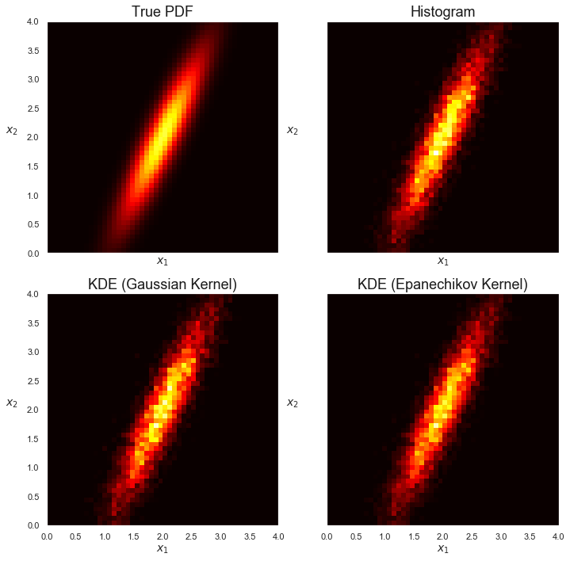

```python
h_gaussian = 0.02
h_epanechikov = 0.05

(pdf_KDE_gauss, pdf_KDE_epa) = compute_KDE_pdf(npts, h_gaussian, h_epanechikov, X, xx, Xgrid)

# Compare the four individual PDF.
figName = '2D_PDF_estimation_bw_too_small'
compare_PDF(figName)
```

The KDE PDF cross-sections are almost carbon copies of the noisy histogram one.

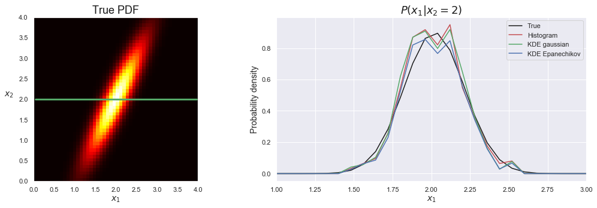

```python
# Compare the individual PDF along an horizontal cross section passing through the PDF origin.
figName = '2D_PDF_conditional_bw_too_small'
compare_conditional_PDF(figName)
```

## Examples with bandwith values that are *too large*.

The KDE-based PDF are overly smoothed. Their signal/noise ratios are good but there is a loss in spatial resolution.

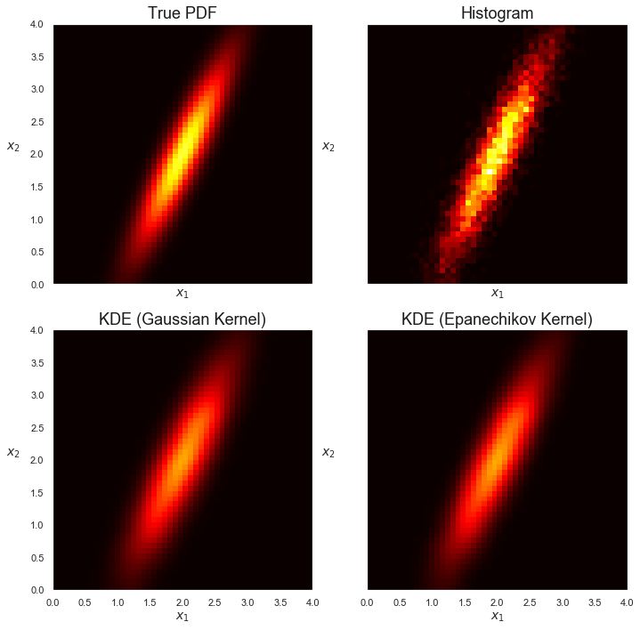

```python
h_gaussian = 0.15
h_epanechikov = 0.3

(pdf_KDE_gauss, pdf_KDE_epa) = compute_KDE_pdf(npts, h_gaussian, h_epanechikov, X, xx, Xgrid)

# Compare the four individual PDF.
figName = '2D_PDF_estimation_bw_too_large'
compare_PDF(figName)
```

The KDE PDF cross-sections are more extended than the real PDF. Histogram results have a finer spatial resolution.

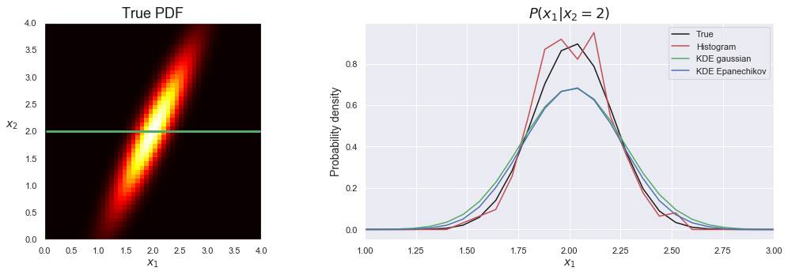

```python
# Compare the individual PDF along an horizontal cross section passing through the PDF origin.
figName = '2D_PDF_conditional_bw_too_large'
compare_conditional_PDF(figName)
```

## Examples with bandwith values that are *just right*.

The KDE-based PDF are still noisy but their 2-D extents are similar to the real ones.

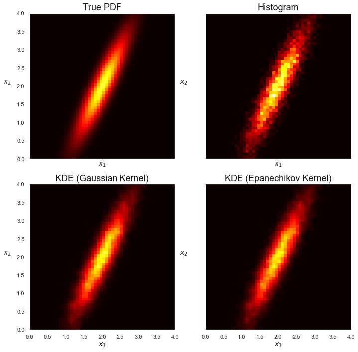

```python
h_gaussian = 0.05
h_epanechikov = 0.1

(pdf_KDE_gauss, pdf_KDE_epa) = compute_KDE_pdf(npts, h_gaussian, h_epanechikov, X, xx, Xgrid)

# Compare the four individual PDF.
figName = '2D_PDF_estimation_bw_just_right'
compare_PDF(figName)
```

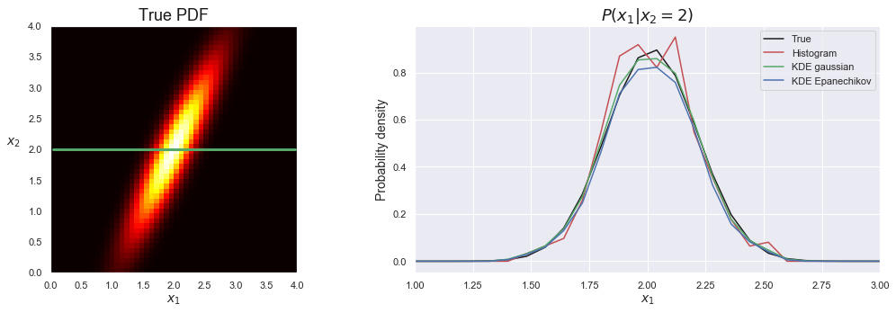

```python
# Compare the individual PDF along an horizontal cross section passing through the PDF origin.
figName = '2D_PDF_conditional_bw_just_right'
compare_conditional_PDF(figName)
```